# HS_609_Verbal_Autopsy_Child

Carmen Chan, Neha Shah, Shuhao Zhou, Shannon Walsh

30 March, 2022

```r
getwd()
```

```
## [1] "/Users/shannonwalsh/Desktop/MIT Project/Data"
```

```r
df_va_original <- read.csv("./IHME_PHMRC_VA_DATA_CHILD_Y2013M09D11_0.csv")
```

```r
str(df_va_original)
```

```
## 'data.frame':    2064 obs. of  423 variables:
##  $ site            : chr  "AP" "Dar" "UP" "Pemba" ...
##  $ module          : chr  "Child" "Child" "Child" "Child" ...
##  $ gs_code34       : chr  "X20" "B54" "B05" "J12" ...
##  $ gs_text34       : chr  "Bite of Venomous Animal" "Malaria" "Measles" "Pneumonia" ...
##  $ va34            : int  2 9 10 17 1 17 14 16 14 21 ...
##  $ gs_code46       : chr  "X20" "B54" "B05" "J12" ...
##  $ gs_text46       : chr  "Bite of Venomous Animal" "Malaria" "Measles" "Pneumonia" ...
##  $ va46            : int  2 9 10 17 1 17 14 16 14 21 ...
##  $ gs_code55       : chr  "X20" "B54" "B05" "J12" ...
##  $ gs_text55       : chr  "Bite of Venomous Animal" "Malaria" "Measles" "Pneumonia" ...
##  $ va55            : int  19 8 6 10 7 10 26 21 26 20 ...
##  $ gs_comorbid1    : logi  NA NA NA NA NA NA ...
##  $ gs_comorbid2    : logi  NA NA NA NA NA NA ...
##  $ gs_level        : chr  "GS Level 1" "GS Level 1" "GS Level 2" "GS Level 1" ...
```

[output cut: 86 more lines]

```r
library(dplyr)
```

**Some of the columns were dropped as they are irrelevant/duplicated or not informative (for example, the frequency of the words doesn’t provide much information without a context)**

```r
# Drop columns that are not necessary
df_va <- subset(df_va_original, select = -c(gs_code34,va34,gs_code46,gs_text46,va46,gs_code55,gs_text55,va55,gs_comorbid1,gs_comorbid2,gs_level,g1_01d,g1_01m,g1_01y,g1_05,g1_06d,g1_06m,g1_06y,g1_07a,g1_07b,g1_07c,g1_08,g1_09,g1_10,g2_01,g2_02,g2_03ad,g2_03am,g2_03ay,g2_03bd,g2_03bm,g2_03by,g2_03cd,g2_03cm,g2_03cy,g2_03dd,g2_03dm,g2_03dy,g2_03ed,g2_03em,g2_03ey,g2_03fd,g2_03fm,g2_03fy,g3_01,g4_02,g4_03a,g4_03b,g4_04,g4_05,g5_05,g5_06a,g5_06b,g5_07,g5_08,word_diseas,word_final,word_child,word_condit,word_digest,word_glucos,word_bodi,word_tetanus,word_hand,word_failur,word_reduc,word_son,word_breath,word_look,word_till,word_spot,word_proper,word_medic,word_found,word_girl,word_ray,word_babi,word_privat,word_reason,word_poison,word_bring,word_renal,word_rash,word_healthi,word_interview,word_acquir,word_accid,word_test,word_cough,word_respiratori,word_mother,word_traffic,word_hospit,word_come,word_abdomen,word_abl,word_result,word_pregnanc,word_suffer,word_check,word_pass,word_famili,word_die,word_road,word_colleg,word_dengu,word_doctor,word_drown,word_tumor,word_cardio,word_eat,word_fall,word_examin,word_acidosi,word_fire,word_fit,word_sepsi,word_nilouf,word_happen,word_head,word_headach,word_skin,word_blood,word_home,word_hypertens,word_immedi,word_bad,word_inject,word_left,word_leg,word_daughter,word_malnutrit,word_milk,word_clock,word_anemia,word_nilof,word_complain,word_hour,word_nurs,word_snake,word_pain,word_pneumonia,word_polic,word_provid,word_boy,word_recov,word_malaria,word_asthma,word_explain,word_scan,word_gandhi,word_born,word_lung,word_stomach,word_difficulti,word_weak,word_client,word_time,word_told,word_transfus,word_treat,word_unconsci,word_water,word_loos,word_week,word_stool,word_ill,word_lot,word_jaundic,word_communiti,word_health,word_deliv,word_drink,word_servic,word_fine,word_eye,word_particip,word_money,word_chest,word_increas,word_live,word_expir,word_normal,word_brain,word_stay,word_urin,word_remov,word_admit,word_bite,word_center,word_measl,word_kept,word_especi,word_neck,word_serious,word_due,word_care,word_day,word_pox,word_hiv,word_icu,word_start,word_nose,word_leukemia,word_caus,word_near,word_morn,word_vomit,word_accord,word_gastric,word_receiv,word_coma,word_father,word_clinic,word_emerg,word_month,word_birth,word_treatment,word_sick,word_dehydr,word_prescrib,word_children,word_motion,word_refer,word_ward,word_certif,word_advis,word_hous,word_medicin,word_play,word_heart,word_diarrhea,word_baby,word_mouth,word_sever,word_shock,word_dead,word_oper,word_night,word_indraw,word_provinci,word_cancer,word_brought,word_even,word_convuls,word_addit,word_deceas,word_take,word_oxygen,word_infect,word_cold,word_misplac,word_swell,word_respond,word_transfer,word_thank,word_cri,word_sudden,word_continu,word_sent,word_stop,word_get,word_fever,word_notic,word_hole,word_kidney,word_bluish,word_yellow,word_injuri,word_pulmonari,c6_11,c6_12,c6_13,c6_14,newid))
```

```r
str(df_va)
```

```
## 'data.frame':    2064 obs. of  148 variables:
##  $ site     : chr  "AP" "Dar" "UP" "Pemba" ...
##  $ module   : chr  "Child" "Child" "Child" "Child" ...
##  $ gs_text34: chr  "Bite of Venomous Animal" "Malaria" "Measles" "Pneumonia" ...
##  $ g4_06    : int  4 4 9 4 5 13 2 4 3 2 ...
##  $ g4_07    : int  2 3 3 2 7 1 2 2 2 1 ...
##  $ g4_08    : chr  "No" "Yes" "Yes" "Yes" ...
##  $ g5_01d   : chr  "20" "Don't Know" "6" "Don't Know" ...
##  $ g5_01m   : chr  "March" "Don't Know" "May" "Don't Know" ...
##  $ g5_01y   : chr  "2005" "2002" "2004" "Don't Know" ...
##  $ g5_02    : chr  "Female" "Female" "Female" "Male" ...
##  $ g5_03d   : chr  "10" "7" "4" "19" ...
##  $ g5_03m   : chr  "August" "April" "December" "March" ...
##  $ g5_03y   : int  2009 2009 2009 2009 2007 2009 2009 2009 2009 2009 ...
##  $ g5_04a   : int  4 7 5 1 6 NA NA NA NA 7 ...
```

[output cut: 86 more lines]

**Transform data type: Change the characters into categorical variables**

```r
df_va[sapply(df_va, is.character)] <- lapply(df_va[sapply(df_va, is.character)],
                                                           as.factor)
```

**Compute table distribution for all the categorical variables**

```r
for (i in 1:ncol(df_va)){
  if (is.factor(df_va[,i])){
    table <- data.frame(table(df_va[,i]))
    colnames(table) <- c(names(df_va)[i],"Freq")
    print(table)
    }
}
```

```
##     site Freq
## 1     AP  449
## 2  Bohol  262
## 3    Dar  467
## 4 Mexico  126
## 5  Pemba  261
## 6     UP  499
##   module Freq
## 1  Child 2064
##                               gs_text34 Freq
## 1                                  AIDS   20
## 2               Bite of Venomous Animal   54
## 3                    Diarrhea/Dysentery  256
## 4                              Drowning   83
## 5                          Encephalitis   41
```

[output cut: 1229 more lines]

```r
df_va <- subset(df_va,select=-c(c1_02,c1_04,c1_05,c1_08a,c1_10,c1_10d,c1_10m,c1_10y,c1_11,c1_15,c1_16,c1_17,c1_18,c1_19_1,c1_19_2,c1_19_3,c1_19_4a,c1_19_4b,c1_19_5,c1_19_6,c1_24,c1_24d,c1_24m,c1_24y,c1_26,c4_07a,c4_31_1,c4_31_2,c4_32,c4_45,c4_47_8b,c5_02_13,c5_02_14,c5_06_2m,c5_06_2d,c5_06_2y,c5_08m,c5_08d,c5_08y))
```

```r
# Compute DOB
df_va$DOB_month <- match(df_va$g5_01m,month.name)
df_va$DOB_str <- paste(df_va$g5_01y,"-",df_va$DOB_month,"-",df_va$g5_01d)
df_va$DOB <- as.POSIXct(df_va$DOB_str, format="%Y - %m - %d",tz="UTC")
df_va <- subset(df_va,select=-c(DOB_str,DOB_month))
```

```r
# Compute DOD
df_va$DOD_month <- match(df_va$g5_03m,month.name)
df_va$DOD_str <- paste(df_va$g5_03y,"-",df_va$DOD_month,"-",df_va$g5_03d)
df_va$DOD <- as.POSIXct(df_va$DOD_str, format="%Y - %m - %d",tz="UTC")
df_va <- subset(df_va,select=-c(DOD_str,DOD_month))
```

```r
df_va <- subset(df_va,select=-c(g5_01d,g5_01m,g5_01y,g5_03d,g5_03m,g5_03y))
```

**c1_22a: Combine “hospital” with “other health facility” to “Health facility”**

```r
df_va$c1_22a <- as.character(df_va$c1_22a)
df_va$c1_22a[df_va$c1_22a=="Hospital"] <- "Health Facility"
df_va$c1_22a[df_va$c1_22a=="Other Health Facility"] <- "Health Facility"
df_va$c1_22a <- as.factor(df_va$c1_22a)
```

**c5_06_1d,c5_06_1m,c5_06_1y: Remove, as most of the records are missing**

```r
df_va <- subset(df_va,select=-c(c5_06_1d,c5_06_1m,c5_06_1y))
```

**Imputation and removal for missing values**  
Check missing values for numeric variables

```r
df_va_num <- select_if(df_va,is.numeric)
```

```r
summary(df_va_num)
```

```
##      g4_06            g4_07            g5_04a           g5_04b
##  Min.   : 1.000   Min.   : 0.000   Min.   : 1.000   Min.   : 1.000
##  1st Qu.: 3.000   1st Qu.: 1.000   1st Qu.: 2.000   1st Qu.: 2.000
##  Median : 5.000   Median : 2.000   Median : 4.000   Median : 5.000
##  Mean   : 5.225   Mean   : 2.436   Mean   : 4.855   Mean   : 5.131
##  3rd Qu.: 6.000   3rd Qu.: 3.000   3rd Qu.: 8.000   3rd Qu.: 8.000
##  Max.   :30.000   Max.   :15.000   Max.   :19.000   Max.   :12.000
##  NA's   :1        NA's   :1        NA's   :792      NA's   :1280
##      g5_04c         c1_08b         c1_20            c1_21
##  Min.   :28.0   Min.   :   2   Min.   :   0.0   Min.   :   0.00
##  1st Qu.:28.0   1st Qu.:2500   1st Qu.:   0.0   1st Qu.:   1.00
##  Median :29.0   Median :2800   Median :  90.0   Median :   7.00
##  Mean   :28.6   Mean   :2798   Mean   : 564.4   Mean   :  37.15
##  3rd Qu.:29.0   3rd Qu.:3100   3rd Qu.: 365.0   3rd Qu.:  20.00
##  Max.   :29.0   Max.   :9999   Max.   :4015.0   Max.   :4015.00
##  NA's   :2059   NA's   :485
##      c1_25            c4_02             c4_07b           c4_08
##  Min.   :   0.0   Min.   :  0.000   Min.   : 0.000   Min.   : 0.000
##  1st Qu.:   0.0   1st Qu.:  0.000   1st Qu.: 0.000   1st Qu.: 0.000
##  Median :  90.0   Median :  2.000   Median : 0.000   Median : 0.000
##  Mean   : 559.2   Mean   :  5.587   Mean   : 1.839   Mean   : 1.701
##  3rd Qu.: 365.0   3rd Qu.:  7.000   3rd Qu.: 3.000   3rd Qu.: 0.000
##  Max.   :4015.0   Max.   :240.000   Max.   :30.000   Max.   :98.000
##
##      c4_10             c4_13             c4_17             c4_19
##  Min.   : 0.0000   Min.   :  0.000   Min.   :  0.000   Min.   :  0.000
##  1st Qu.: 0.0000   1st Qu.:  0.000   1st Qu.:  0.000   1st Qu.:  0.000
##  Median : 0.0000   Median :  0.000   Median :  1.000   Median :  0.000
##  Mean   : 0.3203   Mean   :  3.708   Mean   :  5.487   Mean   :  2.755
##  3rd Qu.: 0.0000   3rd Qu.:  1.000   3rd Qu.:  4.000   3rd Qu.:  1.000
##  Max.   :30.0000   Max.   :300.000   Max.   :740.000   Max.   :740.000
##
##      c4_33             c4_37             c4_49             c5_07_1
##  Min.   : 0.0000   Min.   : 0.0000   Min.   :  0.0000   Min.   :    0.0
##  1st Qu.: 0.0000   1st Qu.: 0.0000   1st Qu.:  0.0000   1st Qu.:    0.0
##  Median : 0.0000   Median : 0.0000   Median :  0.0000   Median :    0.0
##  Mean   : 0.6192   Mean   : 0.9525   Mean   :  0.8075   Mean   :  257.1
##  3rd Qu.: 0.0000   3rd Qu.: 0.0000   3rd Qu.:  0.0000   3rd Qu.:    0.0
##  Max.   :98.0000   Max.   :98.0000   Max.   :150.0000   Max.   :12000.0
##
##     c5_07_2
##  Min.   :    0.0
##  1st Qu.:    0.0
##  Median :    0.0
##  Mean   :  235.9
##  3rd Qu.:    0.0
##  Max.   :13200.0
##
```

**Remove c5_07_1 and c5_07_1 since most of them are 0 (missing in this case)**

```r
df_va <- subset(df_va,select=-c(c5_07_1,c5_07_2))
```

**c1_08b: Re-code “9999” as NA**

```r
df_va$c1_08b[df_va$c1_08b==9999] <- NA
```

**Drop g5_04a,g5_04b,g5_04c and use DOB and DOD to compute the age of death (in years)**

```r
df_va <- subset(df_va,select=-c(g5_04a,g5_04b,g5_04c))
df_va$age_death <- as.numeric(difftime(df_va$DOD, df_va$DOB, units = "days"))/365
```

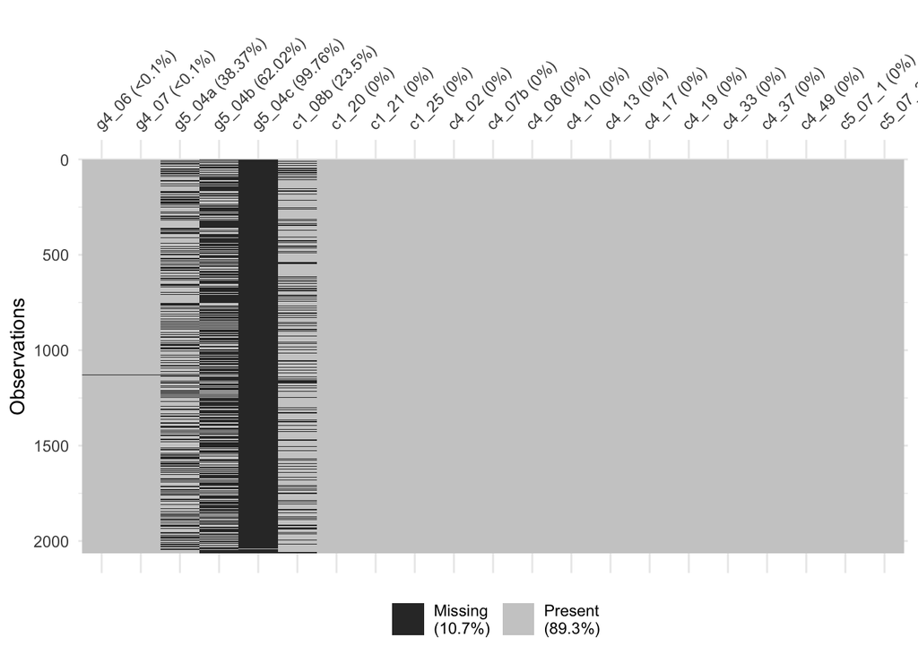

```r
library(naniar)
vis_miss(df_va_num)
```

**Split Training and Test Set**

```r
library(caTools)
set.seed(123)
split = sample.split(df_va$site, SplitRatio = 0.7)
training_set = subset(df_va, split == TRUE)
test_set = subset(df_va, split == FALSE)
```

```r
# Define function impute_cat
impute_cat <- function(df_va){
  cat_num=c()
  for (i in 1:ncol(df_va)){
    if(is.factor(df_va[,i])){
      cat_num <- append(cat_num,i)} # Compute the positions of the columns where the variable is categorical
    }
  for (i in cat_num){
    count_dk <- sum(df_va[,i]=="Don't Know",na.rm=TRUE)
    count_rta <- sum(df_va[,i]=="Refused to Answer",na.rm=TRUE)
    count_missing <- sum(is.na(df_va[,i]),na.rm=FALSE)
    count_whitespace <- sum(df_va[,i]=="",na.rm=TRUE)
    count_all <- count_dk+count_rta+count_missing+count_whitespace
    df_va[,i] <- as.character(df_va[,i])
    if (count_all==10||count_all>15){
      if (count_rta>0){
        df_va[,i][df_va[,i]=="Refused to Answer"] <- "Don't Know"
        }
      if (count_whitespace>0){
        df_va[,i][df_va[,i]==""] <- "Don't Know"
        }
      if (count_missing>0){
        df_va[,i][is.na(df_va[,i])] <- "Don't Know"
        }
      }else{
        if (count_rta>0){
          df_va[,i][df_va[,i]=="Refused to Answer"] <- NA
          }
        if (count_dk>0){
          df_va[,i][df_va[,i]=="Don't Know"] <- NA
          }
        if (count_whitespace>0){
          df_va[,i][df_va[,i]==""] <- NA
        }
      }
    df_va[,i] <- as.factor(df_va[,i])
  }
  return(df_va)
}
```

```r
# Apply impute_cat on both training set and test set
training_set <- impute_cat(training_set)
test_set <- impute_cat(test_set)
```

**Impute missing values of c1_08b with mean of the data by different site groups (fit on training set and transform both sets)**

```r
tapply(training_set$c1_08b,training_set$site, mean, na.rm=TRUE)
```

```
##       AP    Bohol      Dar   Mexico    Pemba       UP
## 2710.312 2971.918 2963.937 2554.524 3058.375 2715.539
```

```r
correct_weight <- function(x1, x2){
  if(is.na(x1)){
    if(x2=="AP"){
      return(2710)
      }
    else if(x2=="Bohol"){
      return(2972)
      }
    else if (x2=="Dar"){
      return(2964)
    }
    else if (x2=="Mexico"){
      return(2555)
    }
    else if (x2=="Pemba"){
      return(3058)
    }
    else{return(2716)}
  }else{
    return(x1)}
}
```

```r
training_set$c1_08b <- apply(training_set[,c("c1_08b","site")], 1, function(x) correct_weight(x[1],x[2]))
test_set$c1_08b <- apply(test_set[,c("c1_08b","site")], 1, function(x) correct_weight(x[1],x[2]))
```

**Remove all the remaining missing data for both sets**

```r
training_set <- training_set[complete.cases(training_set),]
test_set <- test_set[complete.cases(test_set),]
```

**Visualization for EDA**

```r
# Change colname names for training_set_copy
library(plyr)
training_set_copy <- training_set
```

```r
colnames(training_set_copy)<- mapvalues(colnames(training_set_copy), from=c("g4_06","g4_07","g4_08"), to=c("Num_People_Live_at_Address","Num_Rooms_in_Household","Separate_Room_for_Cooking"))
```

```r
colnames(training_set_copy)<- mapvalues(colnames(training_set_copy), from=c("g5_02","c1_01","c1_03"), to=c("Gender","Singleton_or_Multiple_Birth","Mother_Living_or_Deceased"))
```

```r
colnames(training_set_copy)<- mapvalues(colnames(training_set_copy), from=c("c1_06a","c1_07","c1_08b","c1_09","c1_12","c1_13"), to=c("Location_of_Birth","Size_at_Birth","Weight_at_Birth","Sex_of_the_Deceased","Did_the_Baby_Cry","Did_the_Baby_Move"))
```

```r
colnames(training_set_copy)<- mapvalues(colnames(training_set_copy), from=c("num_people_live_at_address","num_rooms_in_household","separate_room_for_cooking"), to=c("Num_People_Live_at_Address","Num_Rooms_in_Household","Separate_Room_for_Cooking"))
```

```r
colnames(training_set_copy)<- mapvalues(colnames(training_set_copy), from=c("c1_14","c1_20","c1_21","c1_22a","c1_25","c4_01","c4_02","c4_03"), to=c("Did_the_Baby_Breathe","Age_at_Onset_of_Illness","Duration_of_Illness", "Location_of_Death","Age_at_Time_of_Death","Fever_During_Illness","Duration_of_Fever_in_Days","Did_the_Fever_Continue_to_Death"))
```

```r
colnames(training_set_copy)<- mapvalues(colnames(training_set_copy), from=c("c4_04","c4_05","c4_06","c4_07b","c4_08","c4_09","c4_10","c4_11","c4_12","c4_13","c4_14","c4_15","c4_16","c4_17","c4_18", "c4_19"), to=c("Severity_of_Fever","Fever_Pattern","Loose_Liquid_Stool", "Highest_Num_Loose_Stool_per_Day_During_Illness","Num_Days_Before_Death_Loose_Stool_Began","Loose_Stool_Cont_Until_Death","Num_Days-Before_Death_Loose_Stool_Stopped","Blood_in_Stool", "Cough_During_Illness", "Duration_of_Cough", "Severity_of_Cough", "Vomitus_after_Coughing", "Difficulty_Breathing", "Duration_of_Difficulty_Breathing", "Fast_Breathing", "Duration_of_Fast_Breathing"))
```

```r
colnames(training_set_copy)<- mapvalues(colnames(training_set_copy), from=c("c4_20", "c4_22", "c4_23", "c4_24", "c4_25", "c4_26","c4_27", "c4_28", "c4_29", "c4_30", "c4_33", "c4_34", "c4_35", "c4_36", "c4_37", "c4_38", "c4_39","c4_40", "c4_41", "c4_42"), to=c("Indrawing_of_Chest", "Breathing_Stridor", "Breathing_Grunting", "Breathing_Wheezing", "Convulsions", "Loss_of_Consciousness", "Duration_Before_Death_LOC_Occurred", "Stiff_Neck", "Bulging_Fontanelle", "Skin_Rash", "Duration_of_Rash", "Blisters_Present_in_Rash", "Limbs_Become_Thin", "Swollen_Legs_or_Feet", "Duration_of_Swelling", "Skin_Flake_Off_in_Patches", "Hair_Color_Change_to_Red/Yellow", "Protruding_Belly", "Pallor_or_Lack_of_Blood", "Swelling_in_Armpits"))
```

```r
colnames(training_set_copy)<- mapvalues(colnames(training_set_copy), from=c("c4_43","c4_44","c4_46", "c4_47_1","c4_47_2", "c4_47_3", "c4_47_4", "c4_47_5","c4_47_6","c4_47_7","c4_47_8a","c4_47_9","c4_47_10","c4_47_11"), to=c("Whitish_Rash_in_Mouth", "Bleeding_Seen","Skin_Turned_Black", "Suffered_Road_Traffic_Injury", "Suffered_a_Fall", "Suffered_Drowning", "Suffered_Poisoning", "Suffered_Bite/Sting", "Suffered_Burn/Fire", "Victim_of_Violence", "Other_Injury", "Unsure_if_Injury_Occurred","Refused_to_Answer_if_Deceased_Suffered_Injury", "Did_Not_Suffer_Injury" ))
```

```r
colnames(training_set_copy)<- mapvalues(colnames(training_set_copy), from=c("c4_48","c4_49","c5_01","c5_02_1","c5_02_2","c5_02_3","c5_02_4","c5_02_5","c5_02_6","c5_02_7","c5_02_8","c5_02_9", "c5_02_10", "c5_02_11a","c5_02_12","c5_04", "c5_05","c5_10", "c5_11", "c5_17", "c5_18", "c5_19"), to=c("Injury_Intentionally_Inflicted_by_Someone","Days_Survived_After_Injury","Sought_Care_While_Ill", "Care_Sought_Traditional_Healer", "Care_Sought_Homeopath", "Care_Sought_Religious_Leader", "Care_Sought_Governmental_Hospital", "Care_Sought_Governmental_Health_Center/Clinic", "Care_Sought_Private_Hospital", "Care_Sought_Community_Based_Practioner", "Care_Sought_Trained_Birth_Attendant", "Care_Sought_Private_Physician", "Care_Sought_Pharmacy", "Care_Sought_Other_Provider", "Care_Sought_Relative/Friend", "Health_Records_for_Deceased", "Granted_Access_to_Health_Records", "Death_Certificate_Issued", "Granted_Access_to_Death_Certificate", "Mother_Ever_Tested_for_HIV", "Mother_HIV_Positive", "Mother_AIDS_Positive"))
```

```r
str(training_set_copy)
```

```
## 'data.frame':    873 obs. of  98 variables:
##  $ site                                          : Factor w/ 6 levels "AP","Bohol","Dar",..: 1 6 3 2 3 5 4 1 3 6 ...
##  $ module                                        : Factor w/ 1 level "Child": 1 1 1 1 1 1 1 1 1 1 ...
##  $ gs_text34                                     : Factor w/ 21 levels "AIDS","Bite of Venomous Animal",..: 2 10 1 17 14 3 15 17 9 2 ...
##  $ Num_People_Live_at_Address                    : int  4 9 5 13 2 7 4 3 5 26 ...
##  $ Num_Rooms_in_Household                        : int  2 3 7 1 2 4 5 2 2 15 ...
##  $ Separate_Room_for_Cooking                     : Factor w/ 2 levels "No","Yes": 1 2 2 2 2 2 1 1 1 2 ...
##  $ Gender                                        : Factor w/ 2 levels "Female","Male": 1 1 1 2 2 2 2 1 1 1 ...
##  $ Singleton_or_Multiple_Birth                   : Factor w/ 2 levels "Multiple","Singleton": 1 2 2 2 2 2 2 2 2 2 ...
##  $ Mother_Living_or_Deceased                     : Factor w/ 3 levels "Don't Know","No",..: 1 1 3 1 3 3 1 1 3 3 ...
##  $ Location_of_Birth                             : Factor w/ 6 levels "Don't Know","Home",..: 3 2 3 2 3 2 3 3 3 2 ...
##  $ Size_at_Birth                                 : Factor w/ 5 levels "About average",..: 1 1 1 1 5 1 1 1 1 1 ...
##  $ Weight_at_Birth                               : chr  "3000.0" "3500.0" "2964" "3624.0" ...
##  $ Sex_of_the_Deceased                           : Factor w/ 2 levels "Female","Male": 1 1 1 2 2 2 2 1 1 1 ...
##  $ Did_the_Baby_Cry                              : Factor w/ 3 levels "Don't Know","No",..: 3 3 3 3 3 3 1 3 3 3 ...
```

[output cut: 84 more lines]

```r
library(ggplot2)
```

**Plot distribution of all the numerical variables with histogram**

```r
hist_list <- list()
z <- 0
for (i in 1:ncol(training_set_copy)){
  if(is.numeric(training_set_copy[,i])){
    z <- z+1
    name <- paste("hist",colnames(training_set_copy)[i],sep="_")
    hist <- ggplot(data=training_set_copy,aes_string(names(training_set_copy)[i]))+
      geom_histogram(fill='lightblue',color='black')+
      labs(x=colnames(training_set_copy)[i],y= "Frequency")
    hist_list[[z]] <- hist
  }
}
```